# CellAssign: Annotating Rhabdomyosarcoma with combined marker gene sets

This notebook dives deeper into using `CellAssign` with marker gene sets derived from the [`PanglaoDB` database](https://panglaodb.se/index.html). Previously we had compared using marker gene sets from a single organ or tissue type using two different databases, `PanglaoDB` or `CellMarker2.0`. We liked the organization of `PanglaoDB`, other than the missing cell ontology IDs, so want to see how `CellAssign` performs when using marker gene sets obtained by combining cell types across organs.

Here we run `CellAssign` using two different gene sets and compare the results to the previous `CellAssign` results using only cell types found in the muscle/connective tissue and to the submitter annotations.

- `combined` refers to a reference gene set that contains all cell types found in muscle, connective tissue, and the immune system.
- `combined_custom` refers to a reference gene set that contains all cell types found in muscle and connective tissue and only Monocytes from the immune system. This is because the only overlap between the submitter annotations and the cells in the immune system found in `PanglaoDB` are Monocytes.
- `muscle_only` refers to a reference gene set that contains only cell types found in muscle and connective tissue. The predictions from using this reference gene set were obtained by running `CellAssign` in the `cell-assign-sarcoma.Rmd` notebook.

## Set Up

```r
library(SingleCellExperiment)
library(ggplot2)

# source helper functions
function_file <- file.path("..", "utils", "cellassign-helper-functions.R")
source(function_file)
```

```r
# Set up paths

# build path to annotated sce file
processed_data_dir <-file.path("..", "data")
processed_sce_file <- glue::glue("{params$library_id}_processed_celltype.rds")
local_processed_sce_path <- file.path(processed_data_dir, params$sample_id, processed_sce_file)

# anndata output
anndata_dir <- file.path("..", "data", "anndata")
anndata_file <- glue::glue("{params$library_id}_anndata.hdf5")
anndata_file <- file.path(anndata_dir, anndata_file)

# reference files for cell marker
ref_dir <- file.path("..", "references")
panglao_file <- file.path(ref_dir, "PanglaoDB_markers_27_Mar_2020.tsv")

# matrix files
panglao_comb_mtx_file <- file.path(ref_dir, "panglao_combined_mtx.csv")
panglao_custom_mtx_file <- file.path(ref_dir, "panglao_combined-custom_mtx.csv")
panglao_muscle_only_mtx_file <- file.path(ref_dir, "panglao_muscle_mtx.csv")

# predictions output
cellassign_outs_dir <- "cellassign_results"

# cellassign predictions
combined_prediction_file <- file.path(
  cellassign_outs_dir,
  glue::glue("{params$library_id}_panglao_combined.tsv")
)
muscle_only_prediction_file <- file.path(
  cellassign_outs_dir,
  glue::glue("{params$library_id}_panglao_muscle.tsv")
)
custom_prediction_file <- file.path(
  cellassign_outs_dir,
  glue::glue("{params$library_id}_panglao_combined-custom.tsv")
)
```

```r
# if the file isn't present, grab it from aws
if(!file.exists(local_processed_sce_path)){

  filename <- basename(local_processed_sce_path)
  local_data_dir <- file.path("..", "data", params$sample_id)
  s3_dir <- "s3://sc-data-integration/scpca/celltype_sce"
  fs::dir_create(local_data_dir)

  sync_call <- glue::glue('op run -- aws s3 sync {s3_dir} {local_data_dir} --exclude "*" --include "{filename}"')
  system(sync_call, ignore.stdout = TRUE)

}


# read in annotated sce
processed_sce <- readr::read_rds(local_processed_sce_path)
```

```r
if(!file.exists(anndata_file)){
 # write out anndata
  scpcaTools::sce_to_anndata(processed_sce, anndata_file = anndata_file)
}
```

## Prep marker gene sets for CellAssign

```r
# read in panglao db
panglao_df <- readr::read_tsv(panglao_file)
```

```r
muscle_cells <- c("Connective tissue", "Smooth muscle", "Skeletal muscle")

# grab all muscle related organs + all immune
panglao_tissue_immune_combined <- panglao_df |>
  dplyr::filter(organ %in% c(muscle_cells, "Immune system"))

panglao_tissue_immune_combined |>
  dplyr::count(`cell type`, `organ`)
```

| cell type | organ | n |
| --- | --- | --- |
| Adipocyte progenitor cells | Connective tissue | 23 |
| Adipocytes | Connective tissue | 120 |
| Airway smooth muscle cells | Smooth muscle | 4 |
| B cells | Immune system | 110 |
| B cells memory | Immune system | 66 |
| B cells naive | Immune system | 69 |
| Basophils | Immune system | 82 |
| Chondrocytes | Connective tissue | 52 |
| Dendritic cells | Immune system | 133 |
| Eosinophils | Immune system | 30 |

[output cut: 29 more lines]

```r
# grab all muscle related organs + monocytes only
custom_marker_genes <- panglao_df |>
  dplyr::filter(organ %in% muscle_cells |
                `cell type` == "Monocytes")

custom_marker_genes |>
  dplyr::count(`cell type`, `organ`)
```

| cell type | organ | n |
| --- | --- | --- |
| Adipocyte progenitor cells | Connective tissue | 23 |
| Adipocytes | Connective tissue | 120 |
| Airway smooth muscle cells | Smooth muscle | 4 |
| Chondrocytes | Connective tissue | 52 |
| Fibroblasts | Connective tissue | 179 |
| Monocytes | Immune system | 102 |
| Myoblasts | Skeletal muscle | 33 |
| Myocytes | Skeletal muscle | 90 |
| Myoepithelial cells | Smooth muscle | 26 |
| Myofibroblasts | Smooth muscle | 9 |

[output cut: 5 more lines]

```r
# list of matrix files to create
mtx_files <- c(panglao_comb_mtx_file,
               panglao_custom_mtx_file)

# if any of them don't exist, make them
if(!any(file.exists(mtx_files))){

  # create rowdata df
  rowdata_df <- rowData(processed_sce) |>
    as.data.frame() |>
    tibble::rownames_to_column("ensembl_id") |>
    dplyr::select(ensembl_id, gene_symbol)

  # create list of marker gene sets
  all_marker_genes <- list(panglao_tissue_immune_combined,
                           custom_marker_genes)
  names(all_marker_genes) <- c("combined", "combined_custom")

  # get binary mtx for combined tissues
  binary_matrix_list <- all_marker_genes |>
    purrr::map(\(gene_list) build_binary_mtx(marker_genes_df = gene_list,
                                             celltype_column = 'cell type',
                                             gene_id_column = 'official gene symbol',
                                             rowdata_df = rowdata_df))

  # export mtx
  purrr::walk2(binary_matrix_list, mtx_files,
               \(binary_mtx, file)
               readr::write_csv(binary_mtx, file))

}
```

```r
# list of output prediction files
prediction_files <- c(combined_prediction_file,
                      custom_prediction_file)
```

```r
# run cell assign with muscle ref
cellassign_calls <- purrr::map2(prediction_files, mtx_files,
                                \(predictions, marker_genes) {
                                  glue::glue("python ../scripts/cell-assign.py \
                                              --input_anndata '{anndata_file}' \
                                              --output_predictions '{predictions}' \
                                              --reference '{marker_genes}'")
                                })

system(cellassign_call)
```

## CellAssign Results

```r
# add muscle only to prediction file list
prediction_files <- c(prediction_files, muscle_only_prediction_file)
names(prediction_files) <- c("combined", "combined_custom", "muscle_only")

# read in prediction scores
all_predictions <- prediction_files |>
  purrr::map(readr::read_tsv)
```

```r
# get final cell type assignments
all_assignments <- purrr::map(all_predictions,
                              get_celltype_assignments)
```

```r
# print table of assignments
all_assignments |>
  purrr::map(\(celltype_assignments){

    # print out table of assignments
    celltype_assignments |>
      dplyr::count(celltype) |>
      dplyr::arrange(desc(n))

  })
```

| celltype | n |
| --- | --- |
| other | 4946 |
| Fibroblasts | 227 |
| Megakaryocytes | 162 |
| T memory cells | 133 |
| Dendritic cells | 106 |
| Monocytes | 99 |
| Myocytes | 76 |
| Airway smooth muscle cells | 31 |
| B cells | 29 |
| Plasma cells | 19 |

[output cut: 19 more lines]

| celltype | n |
| --- | --- |
| other | 4914 |
| Monocytes | 535 |
| Fibroblasts | 237 |
| Myocytes | 107 |
| Stromal cells | 47 |
| Airway smooth muscle cells | 30 |
| Vascular smooth muscle cells | 19 |
| Myoblasts | 16 |
| Satellite cells | 12 |
| Myoepithelial cells | 11 |

[output cut: 4 more lines]

| celltype | n |
| --- | --- |
| other | 5261 |
| Fibroblasts | 284 |
| Myocytes | 161 |
| Stromal cells | 135 |
| Airway smooth muscle cells | 28 |
| Satellite cells | 17 |
| Myoepithelial cells | 16 |
| Myofibroblasts | 11 |
| Vascular smooth muscle cells | 9 |
| Smooth muscle cells | 8 |

[output cut: 4 more lines]

```
NA
```

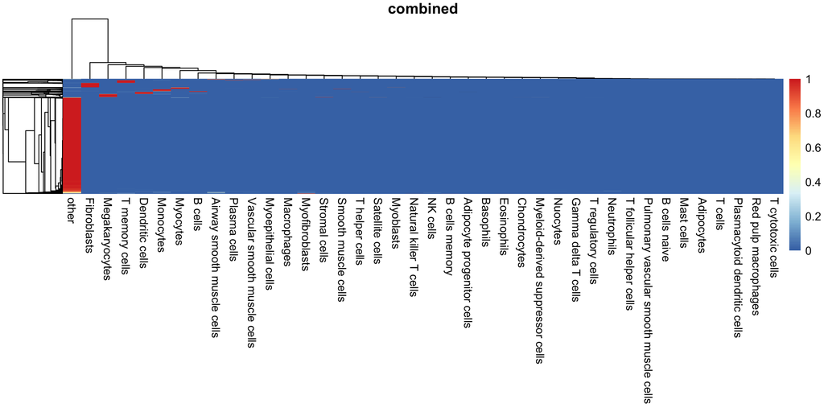

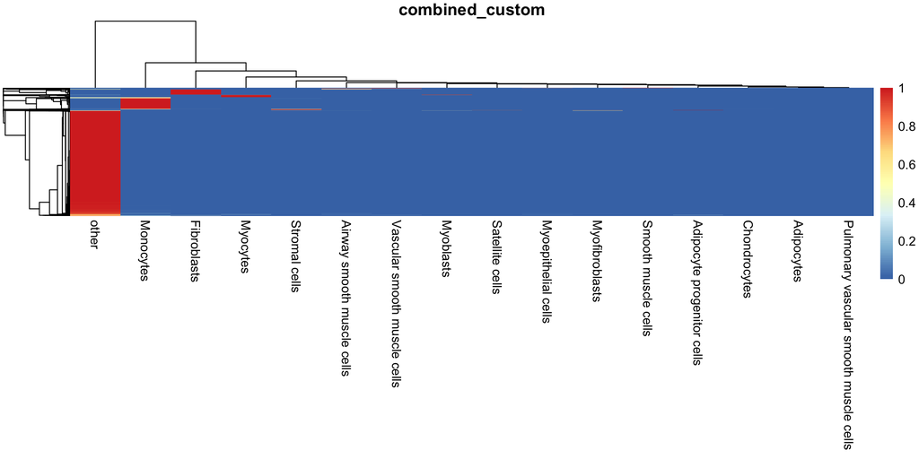

[figure not shown]

```r
# heatmap of prediction scores
all_predictions |>
  purrr::imap(\(prediction_mtx, organ_type){

    prediction_mtx |>
      dplyr::select(-barcode) |>
      as.matrix() |>
      pheatmap::pheatmap(show_rownames = FALSE,
                         main = organ_type)

  })
```

The main conclusion after looking at this is that regardless of the marker gene set, most cells get classified as “other”

## Comparison between marker gene sets

Here we directly compare the annotations between different marker gene sets and the submitter annotations.

```r
# add celltypes to processed sce
processed_sce$combined_assignments <- all_assignments$combined$celltype
processed_sce$combined_custom_assignments <- all_assignments$combined_custom$celltype
processed_sce$muscle_only_assignments <- all_assignments$muscle_only$celltype
```

```r
# extract coldata for easy plotting
coldata_df <- colData(processed_sce) |>
  as.data.frame() |>
  dplyr::select(barcode, celltype, combined_assignments, combined_custom_assignments, muscle_only_assignments) |>
  # classify cells as tumor or normal
  dplyr::mutate(cell_category = dplyr::if_else(stringr::str_detect(celltype, "Tumor"), "Tumor", celltype),
                # remove sub states of myoblast/mesoderm/myocyte
                broad_celltype = stringr::str_remove(celltype, "-\\w$"))
```

```r
compare_refs_heatmap(original_assignment = coldata_df$combined_assignments,
                     cell_assign = coldata_df$muscle_only_assignments,
                     title = "Combined vs. Muscle only")
```

[output not shown]

```r
compare_refs_heatmap(original_assignment = coldata_df$combined_assignments,
                     cell_assign = coldata_df$broad_celltype,
                     title = "Combined vs. Submitter annotations")
```

[output not shown]

```r
compare_refs_heatmap(original_assignment = coldata_df$combined_custom_assignments,
                     cell_assign = coldata_df$muscle_only_assignments,
                     title = "Combined-custom vs. Muscle only")
```

[output not shown]

```r
compare_refs_heatmap(original_assignment = coldata_df$combined_custom_assignments,
                     cell_assign = coldata_df$broad_celltype,
                     title = "Combined-custom vs. Submitter annotations")
```

[output not shown]

```r
compare_refs_heatmap(original_assignment = coldata_df$muscle_only_assignments,
                     cell_assign = coldata_df$broad_celltype,
                     title = "Muscle only vs. Submitter annotations")
```

[output not shown]

## Compare to clustering

This section will compare the various cell type annotations to the cluster assignments. For simplicity, we will use louvain-jaccard graph-based clustering with the default nearest neighbors parameter of 10. We will look at UMAPs and heatmaps of the cluster assignments and cell type assignments. We expect that any assigned cell types should be somewhat correlated to the clusters, in particular for cell types that are less frequent. This means that a single cell type is probably less likely to be spread across multiple clusters.

```r
# cluster sce object
pcs <- reducedDim(processed_sce, "PCA")
clusters <- bluster::clusterRows(pcs,
                                 bluster::NNGraphParam(
                                   cluster.fun = "louvain",
                                   type = "jaccard"
                                 ))
```

```r
# pull out the cell type columns that we want to plot
umap_labels <- c("cluster_assignment",
                 "broad_celltype",
                 "combined_assignments",
                 "combined_custom_assignments",
                 "muscle_only_assignments")

umap_df <- coldata_df |>
  # add clusters and UMAP embeddings to coldata
  dplyr::mutate(
    cluster_assignment = clusters,
    UMAP_1 = reducedDim(processed_sce, "UMAP")[,1],
    UMAP_2 = reducedDim(processed_sce, "UMAP")[,2]
  ) |>
  # combine all the cell type assignments into one column
  tidyr::pivot_longer(cols = umap_labels,
                      names_to = "label_type",
                      values_to = "cell_label") |>
  # relabel other to distinguish from "other" added by forcats
  # Cells categorized by other in CellAssign become Not assigned
  dplyr::mutate(cell_label = dplyr::if_else(cell_label == "other",
                                            "Not assigned",
                                            cell_label)) |>
  dplyr::group_split(label_type) |>
  # only grab the top cell types for each cell type assignment method
  # all other cell types will get grouped as "other"
  purrr::map(\(df)
             dplyr::mutate(df,
                           top_labels = forcats::fct_lump_n(
                             df$cell_label,
                             n = 10
                             ))) |>
  dplyr::bind_rows()
```

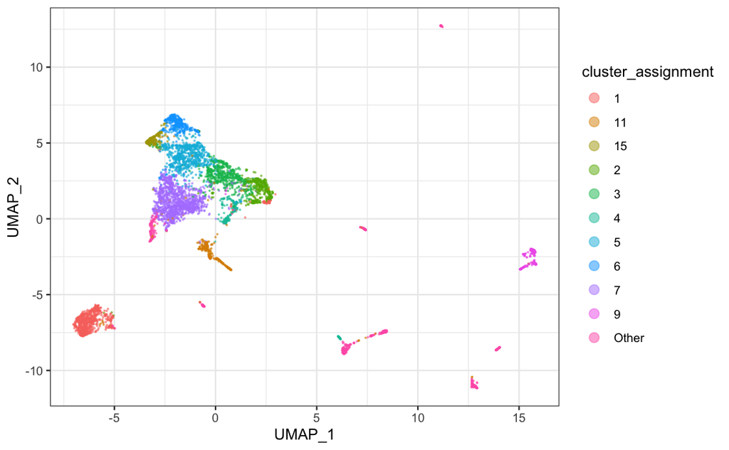

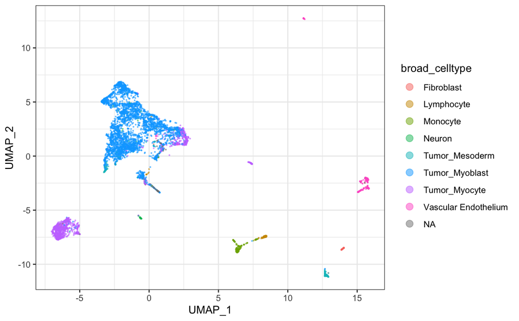

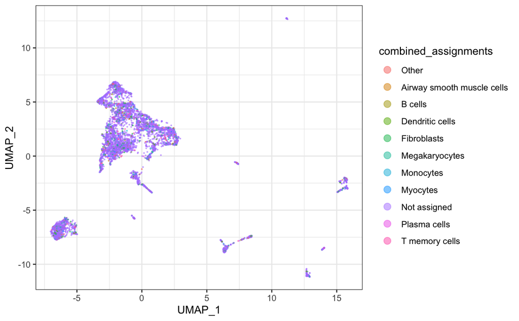

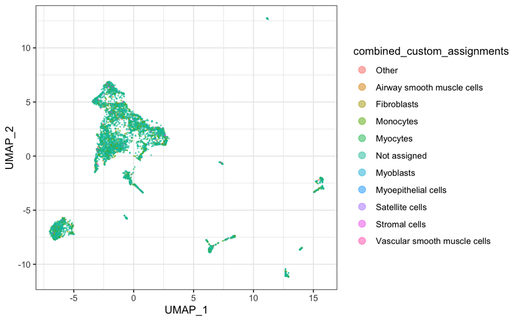

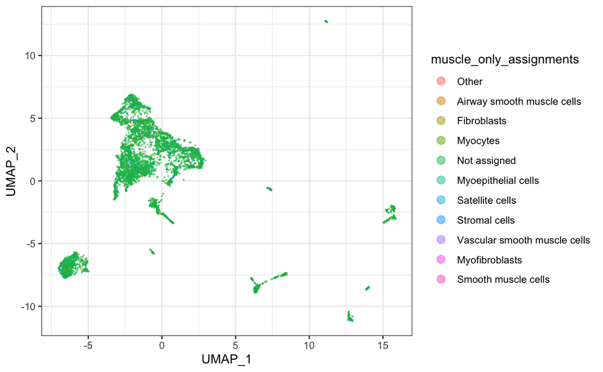

```r
purrr::map(umap_labels,
           \(label){
             plotting_df <- umap_df |>
               dplyr::filter(label_type %in% label)

             ggplot(plotting_df, aes(x = UMAP_1, y = UMAP_2, color = top_labels)) +
               geom_point(size = 0.2, alpha = 0.5) +
               guides(color = guide_legend(override.aes = list(size = 3))) +
               labs(color = label) +
               theme_bw()

           })
```

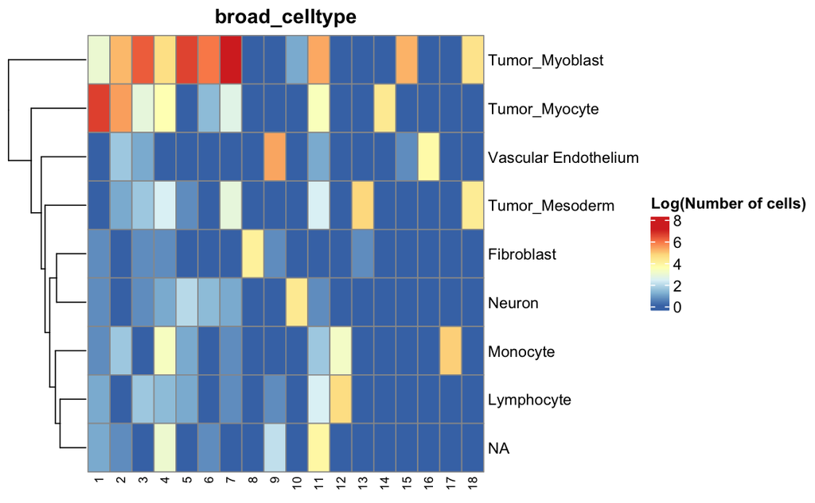

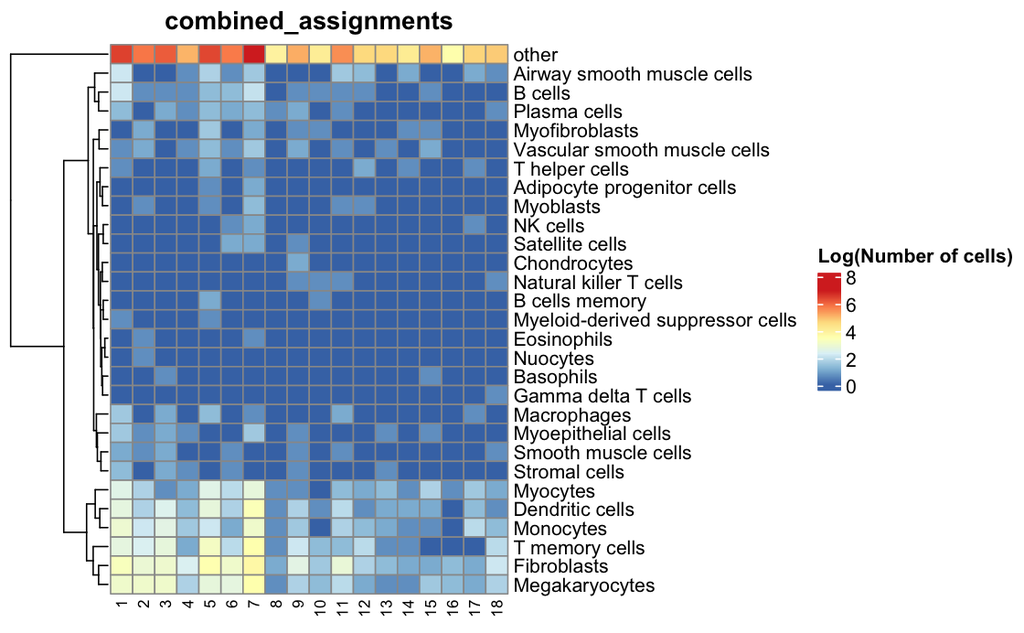

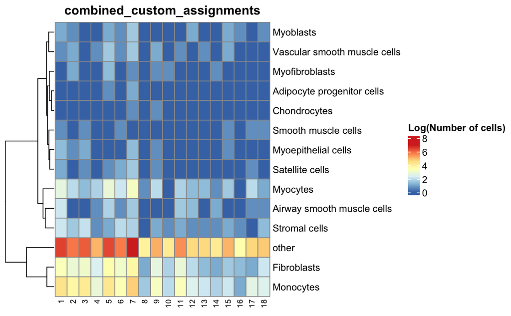

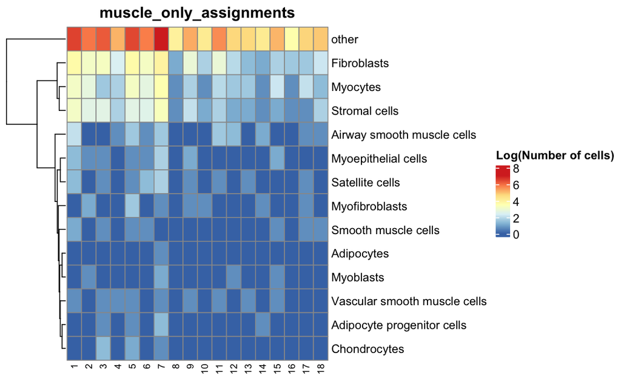

```r
heatmap_labels <- umap_labels[umap_labels != "cluster_assignment"]
purrr::map(heatmap_labels,
           \(label) compare_refs_heatmap(coldata_df[, label],
                                         clusters,
                                         cluster_cols = FALSE,
                                         cluster_rows = TRUE,
                                         title = label))
```

It looks like the smaller immune cell populations (e.g., the T memory cells and Dendritic Cells in the combined annotation) are spread throughout the same cluster that contains cells that are “Not assigned”. These correlate with tumor cells in the submitter annotations. I would have maybe expected to see those cells in their own cluster or separate from the clusters containing tumor cells.

## Conclusions

- Regardless of which combination of cell types we choose from `PanglaoDB` most of the cells get categorized as “other” for this sample. One thing to note is that when using `SingleR` we are able to assign cells to `muscle cells` and `skeletal muscle cells`. Although the assignments from `SingleR` (see `singler-rms-comparison.Rmd`) don’t completely line up with the submitter annotations, identifying cells as muscle cells rather than labeling most of them as “other” does seem more informative to me.
- The more marker genes you have the more time `CellAssign` takes. We already knew this, but this was a new record. It took ~ 2 hours to run the immune + connective tissue with 8 cpus.
- I don’t think adding in the immune system really helped that much. It just made it take longer and then assigned cells to immune cells that were not previously identified in our dataset. Maybe we don’t need to use multiple organs?